# 52414 - lab 1

Yoseph Joffe, Yonatan Kapach

10/5/2023

# *Lab 1: Basic Data Wrangling and Plotting, Distributions*

### Submission Instructions

- This lab will be submitted in pairs (if you don’t have a pair, please contact us) via the submission link in moodle.
- Your final submission should include two files: an `Rmd` file (with your answers filled-in) and an `html` file that was generated automatically by knitting the `Rmd` file using knitr. Name your files as `<ID1>_<ID2>.Rmd` and `<ID1>_<ID2>.html` (insert your ID numbers instead).
- **Grading:** There are $8$ questions with overall $15$ sub-questions. Each sub-question is worth $6\frac{2}{3}$ points to the overall lab grade. The questions vary in length and difficulty level. It is recommended to start with the simpler and shorter questions. Points may be reduced for incorrect naming of files, missing parts and problems in knitting the `Rmd` file and general appearance of the report.
- **Libraries:** The only allowed libraries are listed below (**do not add additional libraries without permission from the course staff**):

```r
library(tidyverse) # This includes dplyr, stringr, ggplot2, ..
library(data.table)
library(ggthemes)
library(reshape2) # melt: change data-frame format long/wide
library(e1071) # skewness and kurtosis
library(rvest)
library(corrplot)
library(moments)
library(spatstat.geom)
library(rworldmap) # world map
```

## Analysis of the World Democracy Index Dataset

The [wikipedia/Democracy_Index](https://en.wikipedia.org/wiki/Democracy_Index) website hosts world-wide data on different measurements of democracy index for world countries. For more information about it, please visit [here](https://web.archive.org/web/20170320185156/http://pages.eiu.com/rs/eiu2/images/Democracy-Index-2012.pdf).

We will focus on analyzing the changes in the index in different countries, as well as the individual components comprising the index, and comparison to other datasets.

### General Guidance

- Your solution should be submitted as a full report integrating text, code, figures and tables. For each question, describe first in the text of your solution what you’re trying to do, then include the relevant code, then the results (e.g. figures/tables) and then a textual description of them.
- In most questions the extraction/manipulation of relevant parts of the data-frame can be performed using commands from the `tidyverse` and `dplyr` R packages, such as `head`, `arrange`, `aggregate`, `group-by`, `filter`, `select`, `summaries`, `mutate` etc.
- When displaying tables, show the relevant columns and rows with meaningful names, and describe the results.
- When displaying figures, make sure that the figure is clear to the reader, axis ranges are appropriate, labels for the axis, title and different curves/bars are displayed clearly (font sizes are large enough), a legend is shown when needed etc. Explain and describe in text what is shown in the figure.
- It could be that in some cases data are missing (e.g. `NA`). Make sure that all your calculations (e.g. taking the maximum, average, correlation etc.) take this into account. Specifically, the calculations should ignore the missing values to allow us to compute the desired results for the rest of the values (for example, using the option `na.rm = TRUE` or `us = "complete.obs"`).

### Questions:

1. **Loading data and basic processing:**
   1. Load the [democracy-index](https://en.wikipedia.org/wiki/Democracy_Index) html into an `R` object, using the `rvest` package.  
      Next, extract the three tables shown in the web-page as `List by region`, `List by country` and `components` into three separate `R` data-frames. Display the top five rows of each table to check that they were loaded correctly.
   2. Display in a new table the `top` five *countries* in terms of the democracy index in *2022*. Show only the country name and the democracy index.  
      Repeat the same with the five `bottom` countries in *2022*.  
      Repeat the same with the five top and bottom countries according to the *average* index value of all the $15$ years between *2006* and *2022* for which data is available in the table `List by country`.
2. **Plotting distributions of groups of countries:**
   1. Make one figure showing seven boxplots representing the distributions of the `democracy index` in *2022* of the different world regions given in the `List by country` table (each boxplot should represent the distribution of all countries within a specific region).  
      Next, for each region that has at least one outlier country, find and list all the outliers that appear in the boxplot.  
      (**Hint:** You may use the `boxplot.stats` command).
   2. Make a figure showing density plots for the same distributions of the `democracy index` in *2022* in the seven different regions. Do the densities resemble to the Normal distribution? Compute the *mean*, *variance*, *skewness* and *kurtosis* for all the distributions, display them in a table and explain what they mean about the empirical distribution of the data.
3. **Comparing countries and showing trends in democracy index:**
   1. Write a function that receives as input a data-frame, and a vector of country names (as strings). The function plots the values of the `democracy index` of these countries in different colors as a function of the year (from *2006* to *2022*), shown on the same graph as curves with different colors or symbols. Use meaningful axis and plot labels, and add an informative legend. Use the function and plot of the `democracy index` for five countries of your choice.  
      Use the same function for the table `List by region` where the seven region names as inserted as input instead of `countries`, to show changes in the world regions `democracy index` over time.
   2. Divide the countries into eight separate groups (clusters) as follows:
- First, countries whose index increased (one cluster) or decreased (another cluster) by at least $1.5$ points between *2006* and *2022*.
- Second, countries whose index increased (one cluster) or decreased (another cluster) by between $0.75$ to $1.5$ points between *2006* and *2022*.
- Next, countries that dropped by at least $0.75$ points after $2006$, and then recovered by at least $0.75$ points in $2022$ compared to the lowest drop.
- Similarly, countries that increased by at least $0.75$ points after $2006$, and then dropped by at least $0.75$ points in $2022$ compared to the highest point.
- Next, countries that had barely changed from $2006$ to $2022$, i.e. that the difference between their highest and lowest index was less than $0.5$ points.
- Finally, all other countries.  
  For each of the eight groups of countries, plot their changes using the function from 2.a. Describe the patterns you see in the different groups.

**Remark:** Don’t worry if some of the groups you get are large with countries with very similar colors, and/or a small graph panel due to a large legend.

4. **Change in category:**  
   For each of the four different regime types (`Full democracy`, `Flawed democracy`, `Hybrid regime`, `Authoritarian`), use the countries democracy index data frame to estimate the probability of a country to go from one such a regime in $2006$ to each of the other four regimes in $2022$. Show the results (sixteen estimated probabilities) in a $4$-by-$4$ table, and also in a heatmap.  
   **Remarks:** Your estimates should simply be the empirical frequencies - for example, if $2$ out $20$ countries moved from `Authoritarian` in $2006$ to `Hybrid regime` in $2022$, then get an estimate of $0.2$ for the probability of such a regime change).  
   Use the table `By regime type` from the democracy index webpage to determine the regime type category based on the democracy index value.
5. **Joining data from additional tables:**
   1. Load tables for the gdp, [population size](https://en.wikipedia.org/wiki/List_of_countries_and_dependencies_by_population), [incarnation rates](https://en.wikipedia.org/wiki/List_of_countries_by_incarceration_rate) and area web pages using the `rvest` library.  
      For each of the four web-page, extract the table for countries into an `R` data-frame.  
      Join the table of the democracy index by country with these four table, using the countries names for joining. Display the top five rows of the joined table
   2. Fit a simple linear regression model with the `democracy index` at $2022$ as the predictor and `GDP (PPP) per capita` (use the CIA estimates) as the response, and report the regression results.  
      Next, Make a scatter plot of the the `GDP (PPP) per capita` (y-axis) vs. the `democracy index` at $2022$, with the fittedthe regression line. Describe your results.  
      Repeat the same steps with `incarnation rate (per 100,000)` as the response
6. **Empirical Cumulative Distribution Function (CDF):**
   1. Let $X$ be a random variable representing the `GDP (PPP) per capita` of a randomly selected *country* in 2022, where countries are selected uniformly at random from all world countries. Compute and plot the empirical CDF of $X$.
   2. Let $Y$ be a random variable representing the `GDP (PPP) per capita` of a randomly selected *person* in the world in 2022, where a person is selected uniformly at random from all world population. Compute and plot the empirical CDF for $Y$ and explain the differences from the distribution for $X$. **Remark:** Use the population size data to compute the empirical CDF for this case. It is possible to use the library `spatstat.geom`.
   3. Let $Z$ be a random variable representing the `GDP (PPP) per capita` of a randomly selected *person* in the world in 2022, where the *location* of the person is selected uniformly at random from all the land area on earth. Compute and plot the empirical CDF for $Y$ and explain the differences from the distribution for $X$. Compare the median, and the $25\%$ and $75\%$ percentiles of $X,Y$ and $Z$. Are they similar or different? explain. **Remark:** Use the countries land area (in $km^2$ or $mi^2$) to compute the empirical CDF for this case. You will need to parse the corresponding column to get the numerical data.
7. **Displaying data on the world map:**  
   Use the `rworldmap` package to display the world map and color each country based on the `average democracy index` across the years from $2006$ to $2022$. Describe the resulting map in a couple of sentences.  
   Next, repeat all parts above , but this time display in the map the `difference` in the index between $2022$ and $2006$.

   **Guidance:** Use the `joinCountryData2Map` and `mapCountryData` commands to make the plots. Keep countries with missing data in white.
8. **Coponents of the Demography Index:**
   1. Join the `components` table with the main table from the previous questions. Display the top five rows. Next, compute the correlation between all pairs of the five democracy components (`Electoral process and pluralism`, `Functioning of government`, `Political participation`, `Political culture` and `Civil liberties`), and plot the resulting $5$-by-$5$ correlations matrix in a heatmap. (It is possible to use the `corrplot` library).
   2. Run multiple linear regression where the covariates are the different democracy sub-indices form the `components` table, and the response variable that you try to predict the `GDP (PPP) per capita` of each country.  
      Show a summary of your regression analysis. What coefficients are significant at significance level $\alpha=0.01$?  
      What countries are outliers? Display the five countries with the highest and lowest residuals in a table. Can you think of other factors contributing to their high/low `GDP (PPP) per capita`?

**Good luck!**

**Solution:** (Fill code, text, plots etc.)

1.a. Loading the data via URL connection:

```r
democracy <- read_html("https://en.wikipedia.org/wiki/Democracy_Index")
all.tables = html_nodes(democracy, "table")

# Use html_table to extract the individual tables from the all.tables object:
df_region <- as.data.frame(html_table(all.tables[4], fill = TRUE))
df_country <- as.data.frame(html_table(all.tables[6], fill = TRUE))
df_comp <- as.data.frame(html_table(all.tables[7], fill = TRUE))
names(df_comp)[2] <- "DeltaRank"

head(df_region, 5)
```

```
##                            Region Coun.tries X2022 X2021 X2020 X2019 X2018
## 1                   North America          2  8.37  8.36  8.58  8.59  8.56
## 2                  Western Europe         21  8.36  8.23  8.29  8.35  8.35
## 3 Latin America and the Caribbean         24  5.79  5.83  6.09  6.13  6.24
## 4            Asia and Australasia         28  5.46  5.46  5.62  5.67  5.67
## 5      Central and Eastern Europe         28  5.39  5.36  5.36  5.42  5.42
##   X2017 X2016 X2015 X2014 X2013 X2012 X2011 X2010 X2008 X2006
## 1  8.56  8.56  8.56  8.59  8.59  8.59  8.59  8.63  8.64  8.64
## 2  8.38  8.40  8.42  8.41  8.41  8.44  8.40  8.45  8.61  8.60
## 3  6.26  6.33  6.37  6.36  6.38  6.36  6.35  6.37  6.43  6.37
## 4  5.63  5.74  5.74  5.70  5.61  5.56  5.51  5.53  5.58  5.44
## 5  5.40  5.43  5.55  5.58  5.53  5.51  5.50  5.55  5.67  5.76
```

```r
head(df_country, 5)
```

```
##           Region X2022.rank       Country      Regime.type X2022 X2021 X2020
## 1  North America         12        Canada   Full democracy  8.88  8.87  9.24
## 2  North America         30 United States Flawed democracy  7.85  7.85  7.92
## 3 Western Europe         20       Austria   Full democracy  8.20  8.07  8.16
## 4 Western Europe         36       Belgium Flawed democracy  7.64  7.51  7.51
## 5 Western Europe         37        Cyprus Flawed democracy  7.38  7.43  7.56
##   X2019 X2018 X2017 X2016 X2015 X2014 X2013 X2012 X2011 X2010 X2008 X2006
## 1  9.22  9.15  9.15  9.15  9.08  9.08  9.08  9.08  9.08  9.08  9.07  9.07
## 2  7.96  7.96  7.98  7.98  8.05  8.11  8.11  8.11  8.11  8.18  8.22  8.22
## 3  8.29  8.29  8.42  8.41  8.54  8.54  8.48  8.62  8.49  8.49  8.49  8.69
## 4  7.64  7.78  7.78  7.77  7.93  7.93  8.05  8.05  8.05  8.05  8.16  8.15
## 5  7.59  7.59  7.59  7.65  7.53  7.40  7.29  7.29  7.29  7.29  7.70  7.60
```

```r
head(df_comp[-c(1,2),], 5)
```

```
##   Rank DeltaRank     Country    Regime.type Overall.score Δ.Score
## 3    1                Norway Full democracy          9.81    0.06
## 4    2           New Zealand Full democracy          9.61    0.14
## 5    3         2     Iceland Full democracy          9.52    0.34
## 6    4                Sweden Full democracy          9.39    0.13
## 7    5         2     Finland Full democracy          9.29    0.02
##   Elec.toral.pro.cessand.plura.lism Func.tioningof.govern.ment
## 3                             10.00                       9.64
## 4                             10.00                       9.29
## 5                             10.00                       9.64
## 6                              9.58                       9.64
## 7                             10.00                       9.64
##   Poli.ticalpartici.pation Poli.ticalcul.ture Civilliber.ties
## 3                    10.00              10.00            9.41
## 4                    10.00               8.75           10.00
## 5                     8.89               9.38            9.71
## 6                     8.33              10.00            9.41
## 7                     8.33               8.75            9.71
```

1.b.

```r
# Create new arranged data frame
country_democ_ind <- df_country %>% arrange(desc(X2022)) %>% select(3, 5)

# Display top and bottom DI countries in 2022
( top_five <- head(country_democ_ind, 5) )
```

```
##       Country X2022
## 1      Norway  9.81
## 2 New Zealand  9.61
## 3     Iceland  9.52
## 4      Sweden  9.39
## 5     Finland  9.29
```

```r
( bottom_five <- tail(country_democ_ind, 5) )
```

```
##                      Country X2022
## 163                    Syria  1.43
## 164 Central African Republic  1.35
## 165              North Korea  1.08
## 166                  Myanmar  0.74
## 167              Afghanistan  0.32
```

```r
# Create new di_mean column and bind to data frame
di_mean <- rowMeans(df_country[5:length(df_country)])
country_democ_ind <- cbind(country_democ_ind, di_mean) %>% arrange(desc(di_mean))

# Display top and bottom

head(country_democ_ind[,-2], 5)
```

```
##      Country  di_mean
## 1 Costa Rica 9.830667
## 2    Uruguay 9.562000
## 3    Austria 9.524667
## 4    Denmark 9.305333
## 5   Tanzania 9.268667
```

```r
tail(country_democ_ind[,-2], 5)
```

```
##         Country  di_mean
## 163      Panama 1.741333
## 164     Comoros 1.700667
## 165       Egypt 1.581333
## 166    Zimbabwe 1.569333
## 167 El Salvador 1.062000
```

We can see that there is no overlap between the *mean* democracy index and the 2022 index for both the top and the bottom 5 countries.

2.a.

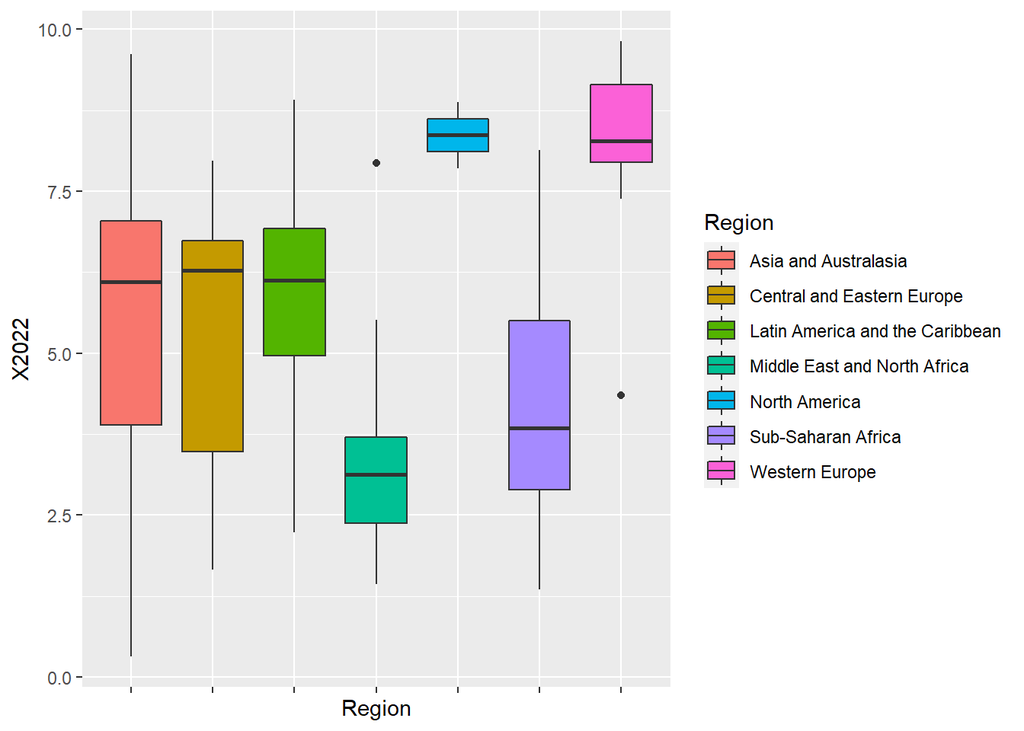

```r
( ggplot(df_country, aes(Region, X2022, fill=Region)) + geom_boxplot() + theme(axis.text.x = element_blank()) )
```

```r
out1 <- boxplot.stats(filter(df_country, Region == "Middle East and North Africa")$X2022)$out
out2 <- boxplot.stats(filter(df_country, Region == "Western Europe")$X2022)$out

# These are the outliers in the Middle East and North Africa region
df_country %>% subset(X2022 == out1)
```

```
##                           Region X2022.rank Country      Regime.type X2022
## 109 Middle East and North Africa         29  Israel Flawed democracy  7.93
##     X2021 X2020 X2019 X2018 X2017 X2016 X2015 X2014 X2013 X2012 X2011 X2010
## 109  7.97  7.84  7.86  7.79  7.79  7.85  7.77  7.63  7.53  7.53  7.53  7.48
##     X2008 X2006
## 109  7.48  7.28
```

```r
# These are the outliers in Western Europe
df_country %>% subset(X2022 == out2)
```

```
##            Region X2022.rank Country   Regime.type X2022 X2021 X2020 X2019
## 22 Western Europe        103  Turkey Hybrid regime  4.35  4.35  4.48  4.09
##    X2018 X2017 X2016 X2015 X2014 X2013 X2012 X2011 X2010 X2008 X2006
## 22  4.37  4.88  5.04  5.12  5.12  5.63  5.76  5.73  5.73  5.69   5.7
```

```r
# Calculating Israel's 2022 democracy index
df_country$X2022[109] # 7.93
```

```
## [1] 7.93
```

```r
# Calculating Turkey's 2022 democracy index
df_country$X2022[22] # 4.35
```

```
## [1] 4.35
```

We see that the Middle East and North Africa has one outlier, Israel, with a democracy index of 7.93, and Europe has one outlier, Turkey, with a democracy index of 4.35.

We note that Israel’s DI is significantly higher than other countries in the region, whereas Turkey’s DI is significantly lower than other countries in Western Europe.

2.b.

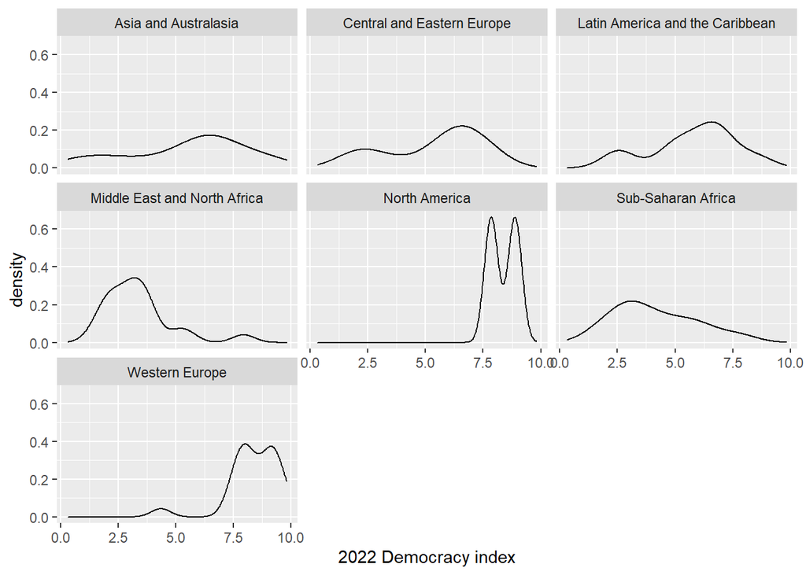

```r
ggplot(df_country, aes(X2022)) +
  geom_density()+
  xlab("2022 Democracy index") +
  facet_wrap(~Region)
```

```r
df_country %>%
  group_by(Region) %>%
  summarise(mean = mean(X2022), variance = var(X2022), skewness = skewness(X2022), kurtosis = kurtosis(X2022))
```

```
## # A tibble: 7 × 5
##   Region                           mean variance skewness kurtosis
##   <chr>                           <dbl>    <dbl>    <dbl>    <dbl>
## 1 Asia and Australasia             5.46    6.68    -0.529     2.32
## 2 Central and Eastern Europe       5.39    4.23    -0.649     1.99
## 3 Latin America and the Caribbean  5.79    3.40    -0.504     2.52
## 4 Middle East and North Africa     3.34    2.22     1.54      5.65
## 5 North America                    8.36    0.530    0         1
## 6 Sub-Saharan Africa               4.14    3.18     0.506     2.37
## 7 Western Europe                   8.36    1.36    -1.86      7.64
```

The mean democracy index of countries in North America and Western Europe is the highest, whereas the Middle East and Africa are the lowest. Asia, Australasia, the rest of Europe and the Americas are about the same (5-6).

However, the variance differs between the regions with Asia and Australasia leading with ~6.68, which means the SD is about 2.5 and some countries there differ with 2.5 points between each other (and probably some even more).

In North America we see a very low variance, but since we only have 2 samples there we cannot really infer much.

The skewness and kurtosis explains what we see in the density plots: The distributions of the regions with negative skewness have a left tail and for the positive skewness a right tail. The higher the skewness (In absolute value) the longer the tail.

The skewness of North America is exactly 0 because we have only 2 samples, which makes the distribution symmetric around the mean.

3.a.

```r
# df is the Data frame of countries/regions, strings is the list of countries/regions to cross reference, and sivug is either "Country" or "Region"
di_graphing <- function(df, strings, sivug) {

  # remove unnecessary columns from data set based on it's sivug (type) and our knowledge of its layout
  if(sivug == "Country"){
    df1 <- df %>% filter(Country %in% strings)
  }
  else if(sivug == "Region"){
    df1 <- df %>% filter(Region %in% strings)
  }
    else{
      stop("Sivug needs to be Country/Region")
    }

  df1 <- df1 %>% select(sivug, matches("^X20[0-2][0-9]$"))

  # fix the names of the data set years
  names(df1) <- sub('X', '', names(df1))

  # organizing the data set
  Year <- names(df1)[-1]
  df2 = cbind(Year = as.numeric(Year), as.data.frame((t(df1))[-1,]))
  colnames(df2) <- c("Year", intersect(df1[,1], strings))
  rownames(df2) <- NULL

  # Reshape data into long format
  data_long <- data.frame(gather(df2, key = sivug, value = "value", -Year))
  data_long$value <- as.numeric(data_long$value)


# Create plot
  ggplot(data_long, aes(x = Year, y = value, color = sivug)) +
    geom_smooth(se = FALSE) +
    ggtitle(paste("Democracy Index 2006-2022 by", sivug)) +
    theme(plot.title = element_text(hjust=0.5)) +
    ylab("Democracy Index") +
    guides(color = guide_legend(title = sivug))

}
```

Now that we’ve written the function, we can apply it to a subset of 5 countries:

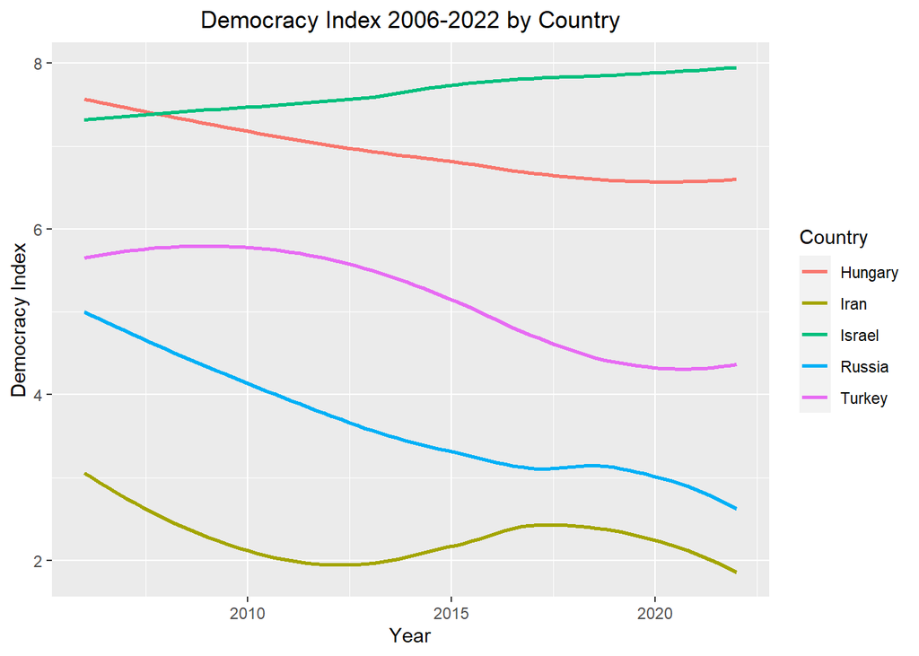

```r
strings1 <- c("Israel", "Iran", "Turkey", "Hungary", "Russia")
di_graphing(df_country, strings1, "Country")
```

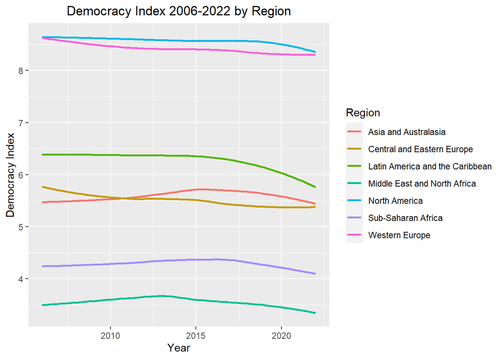

```r
strings2 <- c(df_region$Region[-8])
di_graphing(df_region, strings2, "Region")
```

We can see that democracy index for Hungary, Iran, Israel, Russia and Turkey. We see that of these 5 countries, the only one with an increase in its democracy index over time is Israel.

Additionally, we see a significant decline in Latin America and the Carribbean, whereas in other regions there is little to no change over the last 15 years.

3.b. We now divide our data set into 8 groups:

```r
# create vector of difference between X2022 and X2006
subtract <- (df_country$X2022) - (df_country$X2006)
increased_1.5 <- df_country[which(subtract >= 1.5),]
decreased_1.5 <- df_country[which(subtract <= -1.5),]
increased_0.75 <- df_country[which((1.5 > subtract) & (subtract > 0.75)),]
decreased_0.75 <- df_country[which((-1.5 < subtract) & (subtract < -0.75)),]

# create data frame from numeric columns of df_country
d <- df_country %>% select_if(is.numeric)

# remove column of world ranking of DI
d = d[,!names(d) %in% c("X2022.rank")]

min_row <- apply(d, 1, min)
max_row <- apply(d, 1, max)

down_up_0.75 <- df_country[which(((d$X2006 - min_row) >= 0.75) & (d$X2022 - min_row) >= 0.75),]

up_down_0.75 <- df_country[which(((max_row - d$X2006) >= 0.75) & (max_row - d$X2022) >= 0.75),]

no_change <- df_country[which((max_row - min_row) < 0.5),]

merged <- rbind(increased_1.5, decreased_1.5, increased_0.75, decreased_0.75, down_up_0.75, up_down_0.75, no_change)

all_others <- df_country[!df_country$Country %in% intersect(df_country$Country, merged$Country),]
```

Now, we apply the function from 3a to our 8 groups:

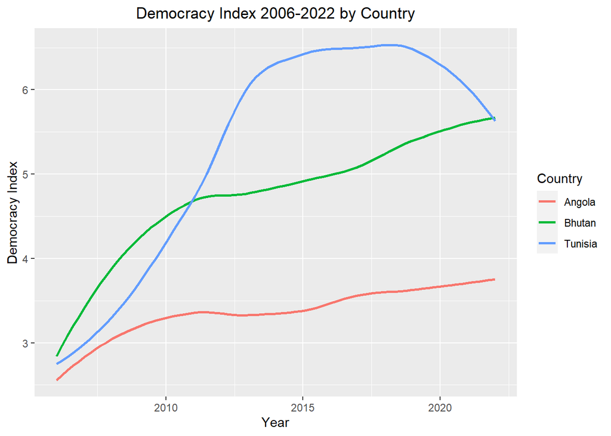

```r
# graphing all 8 clusters
di_graphing(increased_1.5, increased_1.5$Country, "Country")
```

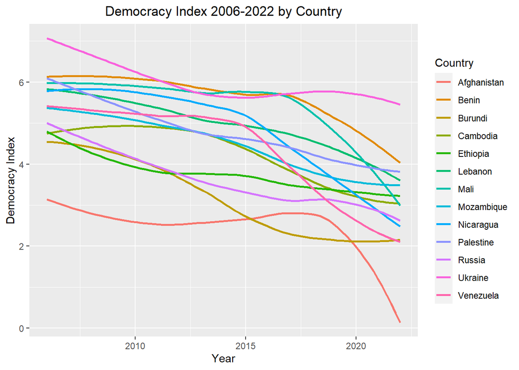

```r
di_graphing(decreased_1.5, decreased_1.5$Country, "Country")
```

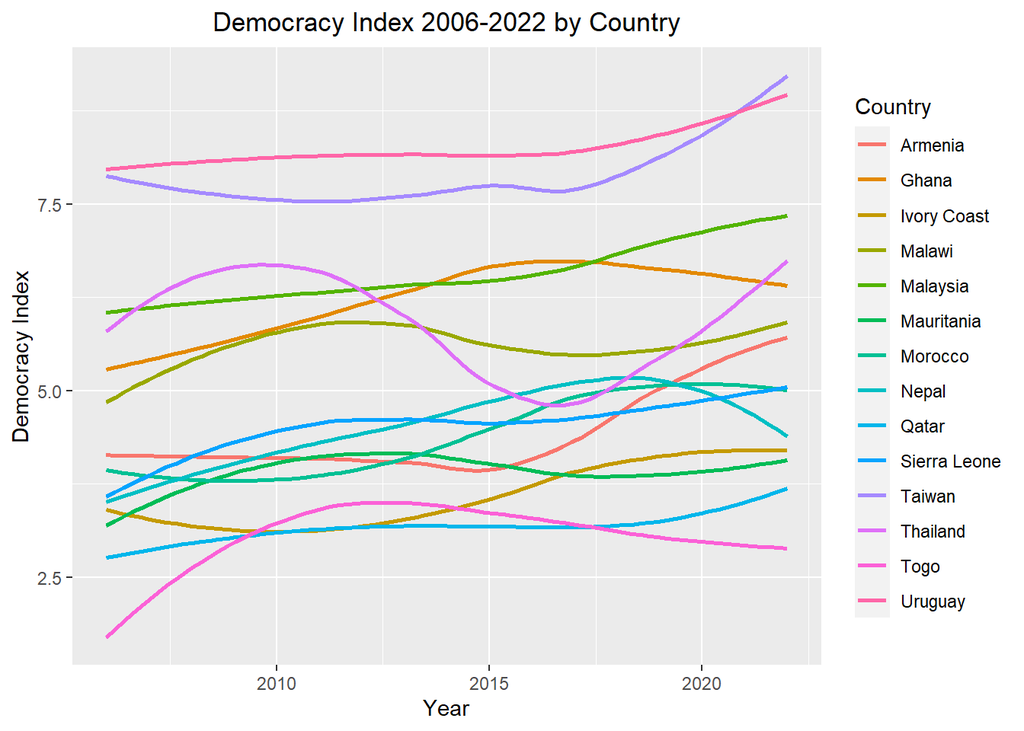

```r
di_graphing(increased_0.75, increased_0.75$Country, "Country")
```

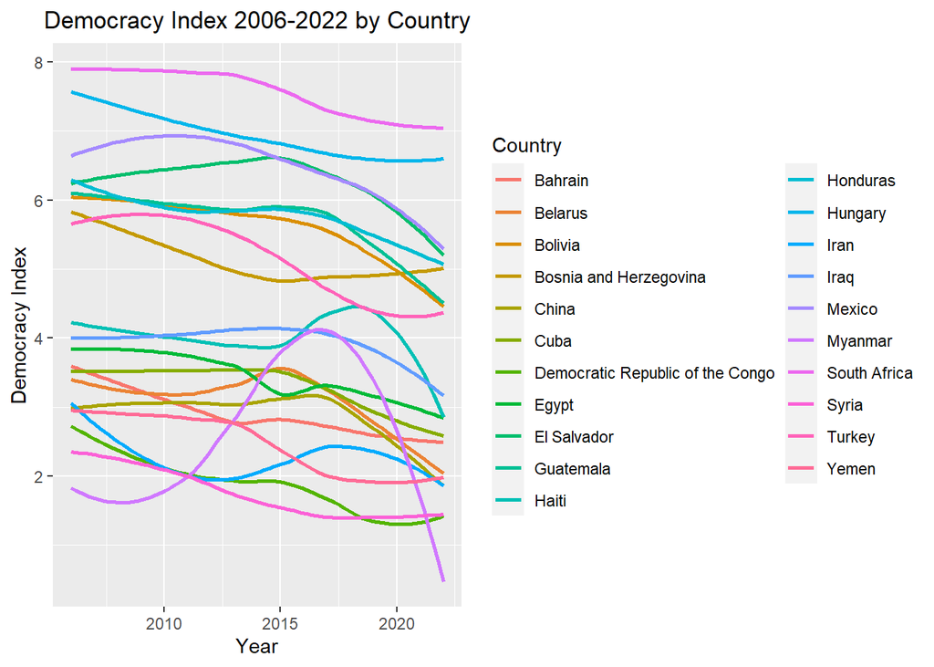

```r
di_graphing(decreased_0.75, decreased_0.75$Country, "Country")
```

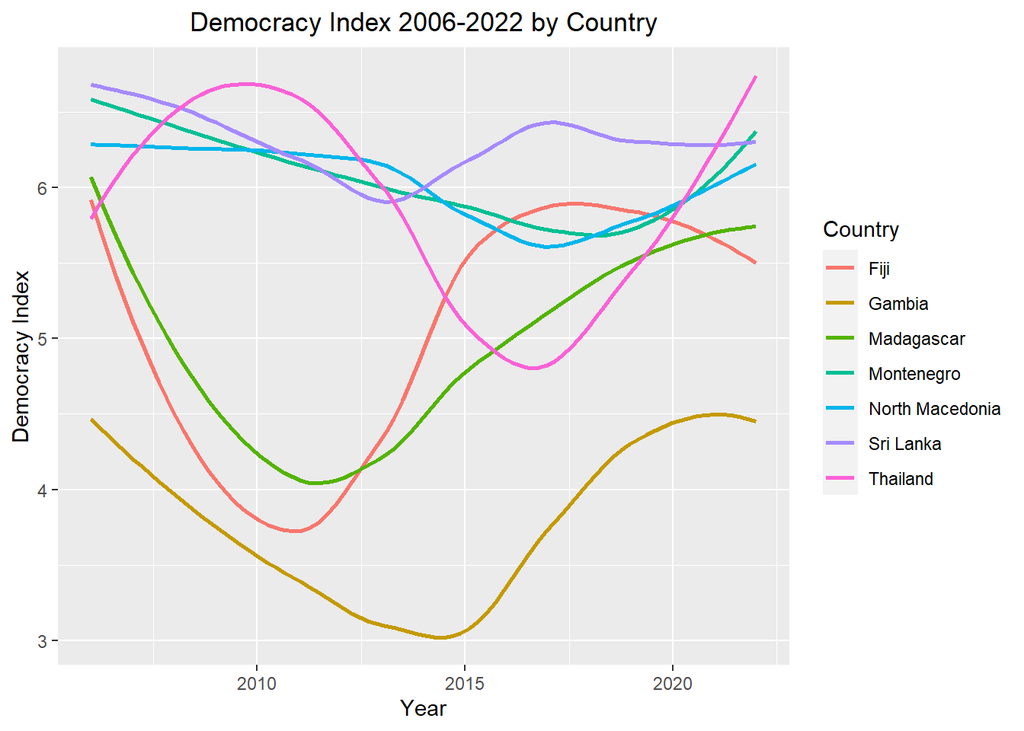

```r
di_graphing(down_up_0.75, down_up_0.75$Country, "Country")
```

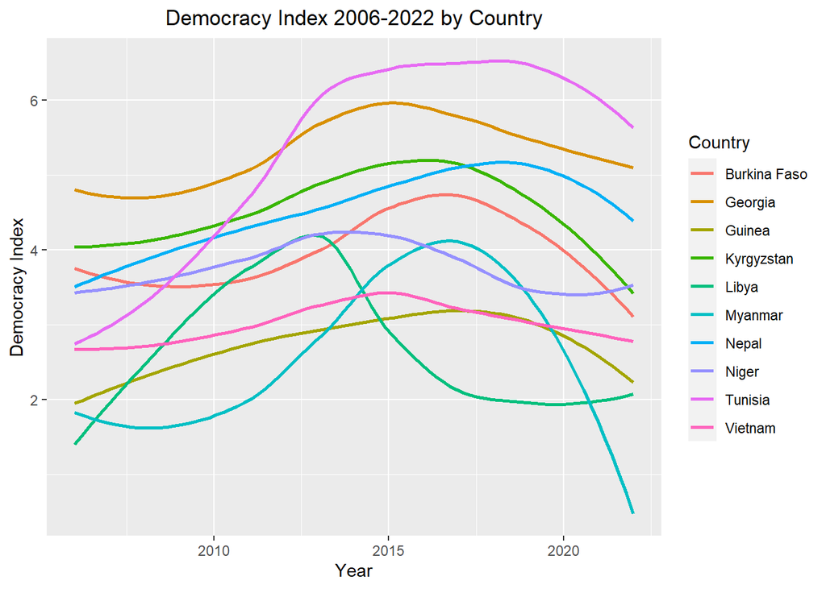

```r
di_graphing(up_down_0.75, up_down_0.75$Country, "Country")
```

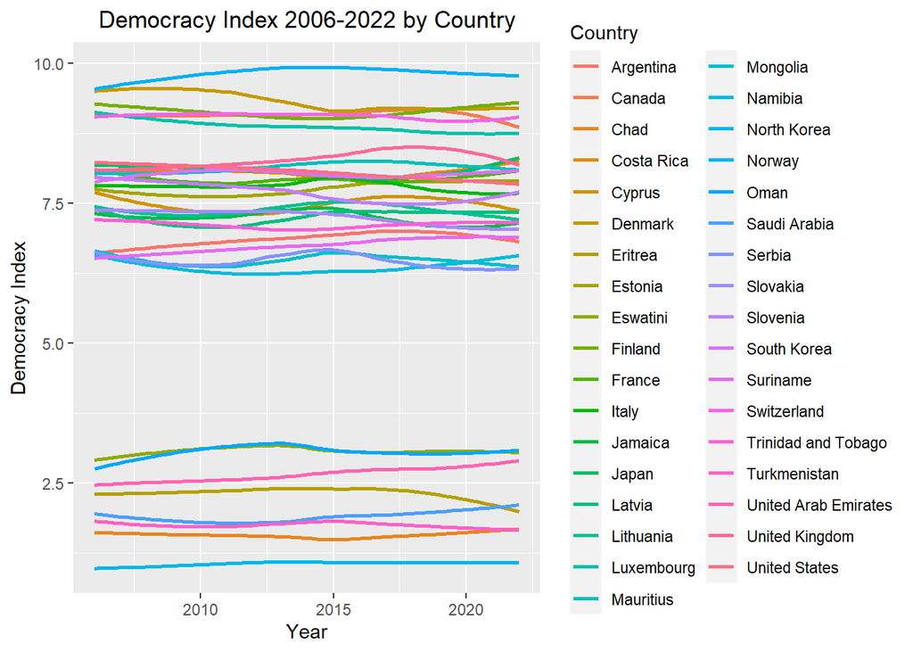

```r
di_graphing(no_change, no_change$Country, "Country")
```

[figure not shown]

```r
di_graphing(all_others, all_others$Country, "Country")
```

First, we will note that there are 4 countries that appear in 2 separate groups: Tunisia, Thailand, Nepal, Myanmar.

There is a lot one can analyse from these graphs. However what stands out most is the fact that most countries have gradual change, although there are a few outliers who have drastic changes from year-to-year.

4. First we’ll create a function that finds out the country regime type based on di:

```r
# logical function to return regime type
regime <- function(di){
  if (di <= 4)
    return("Authoritarian")
  if (di <= 6)
    return("Hybrid regime")
  if (di <= 8)
    return("Flawed democracy")
  else
    return("Full democracy")
}
```

Next we’ll prepare the data:

```r
# Create NA matrix
regimes <- c("Full democracy", "Flawed democracy", "Hybrid regime", "Authoritarian")
pmat <- matrix(nrow = 4, ncol = 4, dimnames = list(paste(regimes, "2006"), paste(regimes, "2022")))

country_num <- length(df_country$Country)

# Add the 2006 regime type column
df_country <- cbind(df_country, X2006.Regime.type = sapply(df_country$X2006, regime))

# Create a matrix with the Cartesian product of regimes (all 16 possibilities) + the relevant indices in pmat
product <- expand.grid(regimes, regimes)
product <- cbind(product, rep(1:4, 4), rep(1:4, each=4))
```

Now we’ll iterate through the product matrix and for every possibility we’ll enter the number of countries matching it, divided by the total number (the empirical probability) and then fill the matrix pmat:

```r
for(i in 1:16){
  count <- nrow(filter(df_country, X2006.Regime.type == product[i,1] & Regime.type == product[i,2]))
  pmat[product[i,3], product[i,4]] <- count / country_num
}

print(pmat)
```

```
##                       Full democracy 2022 Flawed democracy 2022
## Full democracy 2006             0.1197605            0.03592814
## Flawed democracy 2006           0.0239521            0.22155689
## Hybrid regime 2006              0.0000000            0.02994012
## Authoritarian 2006              0.0000000            0.00000000
##                       Hybrid regime 2022 Authoritarian 2022
## Full democracy 2006           0.00000000        0.000000000
## Flawed democracy 2006         0.06586826        0.005988024
## Hybrid regime 2006            0.09580838        0.071856287
## Authoritarian 2006            0.05389222        0.275449102
```

As expected:

```r
sum(pmat) # =1
```

```
## [1] 1
```

Now in a heatmap:

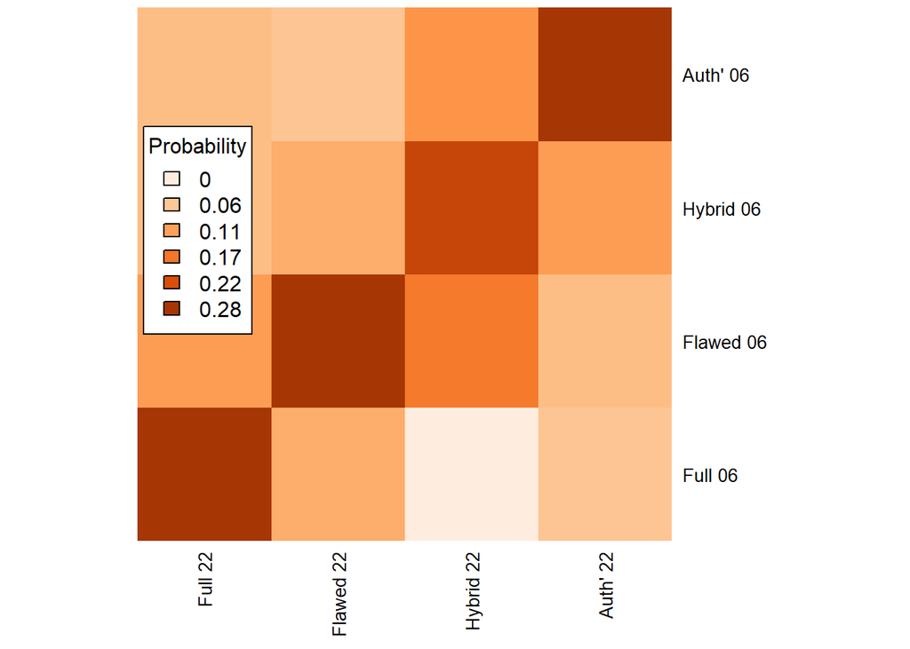

```r
# create vector of legend values
leg_vals <- round(seq(from = 0, to = max(pmat), by = max(pmat)/5), 2)
library(RColorBrewer)

# Changing dimnames so we can see the full string in the heatmap
short_regimes <- c("Full", "Flawed", "Hybrid", "Auth'")
rownames(pmat) <- paste(short_regimes, "06")
colnames(pmat) <- paste(short_regimes, "22")

heatmap(pmat, Colv = NA, Rowv = NA, col=colorRampPalette(brewer.pal(5, "Oranges"))(25), scale="column", cexRow = 1, cexCol = 1)
legend(x = "topleft", inset = 0.05, legend = leg_vals, title = "Probability", fill = colorRampPalette(brewer.pal(5, "Oranges"))(6))
```

We can infer from pmat that drastic changes of regime type are not likely to occur over the years (The probability is 0 from Authoritarian to Full/Flawed or from Full to Hybrid/Auth).

It is even easier to see it in the heatmap. The diagonal has darker colors meaning it is more likely for a country to have the same regime type it had in 2006 than any of the other types.

5.a.

```r
# Importing the tables as data frames
gdp <- read_html("https://en.wikipedia.org/wiki/List_of_countries_by_GDP_(PPP)_per_capita")
df_gdp <- as.data.frame(html_table(html_nodes(gdp, "table")[2]))

population <- read_html("https://en.wikipedia.org/wiki/List_of_countries_and_dependencies_by_population")
df_pop <- as.data.frame(html_table(html_nodes(population, "table")[2]))

incarceration <- read_html("https://en.wikipedia.org/wiki/List_of_countries_by_incarceration_rate")
df_inc <- as.data.frame(html_table(html_nodes(incarceration, "table")[2]))

area <- read_html("https://en.wikipedia.org/wiki/List_of_countries_and_dependencies_by_area")
df_area <- as.data.frame(html_table(html_nodes(area, "table")[2]))
```

```r
# Fixing column names for join
names(df_gdp)[1] <- "Country"
names(df_pop)[2] <- "Country"
names(df_inc)[1] <- "Country"
names(df_area)[2] <- "Country"

# Fixing strings in $Country to match as possible. removing '*', '[Note]' and anything inside '()' using regex.
df_gdp$Country <- df_gdp$Country %>% str_replace_all(fixed("*"), "") %>% str_trim()
df_pop$Country <- df_pop$Country %>% str_replace_all("\\(.+\\)", "") %>% str_trim()
df_inc$Country <- df_inc$Country %>% str_replace_all(fixed("*"), "") %>% str_replace_all(fixed("[Note]"), "") %>% str_trim()
df_area$Country <- df_area$Country %>% str_replace_all("\\(.+\\)", "") %>% str_trim()

# Multiple full join to include all rows
df_list = list(df_country, df_gdp, df_pop, df_inc, df_area)
full_df_country <- df_list %>% reduce(full_join, by='Country')

head(full_df_country, 5)
```

```
##         Region.x X2022.rank       Country      Regime.type X2022 X2021 X2020
## 1  North America         12        Canada   Full democracy  8.88  8.87  9.24
## 2  North America         30 United States Flawed democracy  7.85  7.85  7.92
## 3 Western Europe         20       Austria   Full democracy  8.20  8.07  8.16
## 4 Western Europe         36       Belgium Flawed democracy  7.64  7.51  7.51
## 5 Western Europe         37        Cyprus Flawed democracy  7.38  7.43  7.56
##   X2019 X2018 X2017 X2016 X2015 X2014 X2013 X2012 X2011 X2010 X2008 X2006
## 1  9.22  9.15  9.15  9.15  9.08  9.08  9.08  9.08  9.08  9.08  9.07  9.07
## 2  7.96  7.96  7.98  7.98  8.05  8.11  8.11  8.11  8.11  8.18  8.22  8.22
## 3  8.29  8.29  8.42  8.41  8.54  8.54  8.48  8.62  8.49  8.49  8.49  8.69
## 4  7.64  7.78  7.78  7.77  7.93  7.93  8.05  8.05  8.05  8.05  8.16  8.15
## 5  7.59  7.59  7.59  7.65  7.53  7.40  7.29  7.29  7.29  7.29  7.70  7.60
##   X2006.Regime.type UN.Region IMF.5..6. IMF.5..6..1 World.Bank.7.
## 1    Full democracy  Americas    60,177        2023        52,085
## 2    Full democracy  Americas    80,035        2023        69,288
```

[output cut: 39 more lines]

At this point we have a combined data frame with all of the rows of all given data frames, matched by the column values.

Now, we need to deal with ’NA’s so we can fit a linear regression model.

5.b.

```r
names(full_df_country)[26] <- "CIA.est"
names(full_df_country)[36] <- "inc_rate"

# Dropping NA values in the relevant columns for regression
full_df_country$inc_rate[which(full_df_country$inc_rate == "—")] <- NA
reg1_df <- full_df_country %>% drop_na(CIA.est) %>% drop_na(X2022)
reg2_df <- full_df_country %>% drop_na(inc_rate) %>% drop_na(X2022)

# Converting strings to numeric
reg1_df$CIA.est %<>% str_replace_all(fixed(","), "") %>%  as.numeric()
reg2_df$inc_rate <- as.numeric(reg2_df$inc_rate)
```

We fit a simple linear regression model for GDP ~ Democracy index:

```r
reg1_lm <- lm(CIA.est ~ X2022, reg1_df)
summary(reg1_lm)
```

```
##
## Call:
## lm(formula = CIA.est ~ X2022, data = reg1_df)
##
## Residuals:
##    Min     1Q Median     3Q    Max
## -27624 -11755  -2982   7029  79827
##
## Coefficients:
##             Estimate Std. Error t value Pr(>|t|)
## (Intercept)  -6667.2     3523.2  -1.892   0.0602 .
## X2022         5279.8      599.5   8.807  1.7e-15 ***
## ---
## Signif. codes:  0 '***' 0.001 '**' 0.01 '*' 0.05 '.' 0.1 ' ' 1
##
## Residual standard error: 18410 on 165 degrees of freedom
## Multiple R-squared:  0.3198, Adjusted R-squared:  0.3156
## F-statistic: 77.56 on 1 and 165 DF,  p-value: 1.698e-15
```

We can see the estimator for the intercept is -6667.2 and estimator for the slope of the linear line is 5279.8. This means there is a positive linear connection; the higher the DI - the higher the GDP.

The p.value for the slope estimator means we can be sure with confidence level of 0.001 that the slope is not 0 - i.e our predictor has an impact on the response. $R^2$ though is 0.3198 which means the model doesn’t explain the variance of the data very well.

Now let’s plot the Y and X axes:

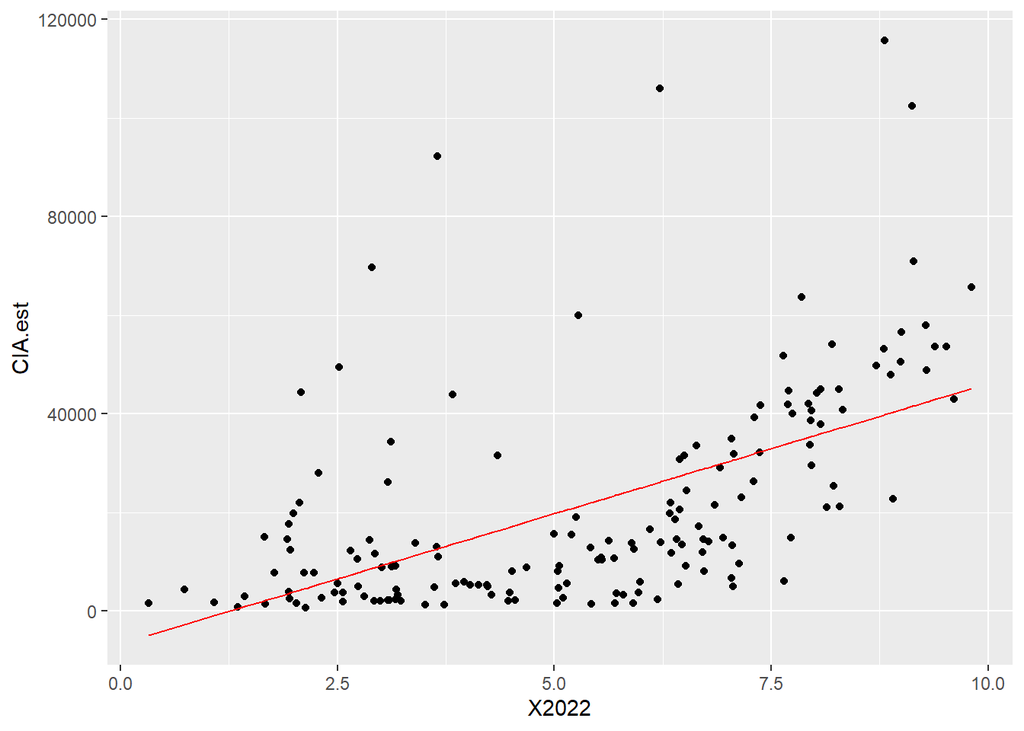

```r
ggplot(reg1_df) + geom_point(aes(X2022, CIA.est)) + geom_line(aes(X2022, reg1_lm$fitted.values), color="red")
```

The graph supports our findings:  
* There is a positive connection between x and y, they increase together.  
* We see variance in the y-axis that our model can’t explain - i.e we don’t see a strong linear connection.

Now we’ll do the same for Incarnation rate ~ Democracy index:

```r
reg2_lm <- lm(inc_rate ~ X2022, reg2_df)
summary(reg2_lm)
```

```
##
## Call:
## lm(formula = inc_rate ~ X2022, data = reg2_df)
##
## Residuals:
##     Min      1Q  Median      3Q     Max
## -132.92  -81.94  -36.21   39.75  450.53
##
## Coefficients:
##             Estimate Std. Error t value Pr(>|t|)
## (Intercept) 158.2880    22.3276   7.089 4.01e-11 ***
## X2022        -0.7536     3.7828  -0.199    0.842
## ---
## Signif. codes:  0 '***' 0.001 '**' 0.01 '*' 0.05 '.' 0.1 ' ' 1
##
## Residual standard error: 113.6 on 161 degrees of freedom
## Multiple R-squared:  0.0002465,  Adjusted R-squared:  -0.005963
## F-statistic: 0.03969 on 1 and 161 DF,  p-value: 0.8423
```

The estimators for the intercept and slope are 158.3~ and -0.7536 correspondingly. Notice the slope estimator is really low which means the regression line is almost flat.

P.value for the slope estimator is really high which means we can’t be sure (even with 0.1 confidence interval) that the predictor has impact on the response. $R^2$ is really low which means the model doesn’t explain the variance of the response.

Let’s plot the graph:

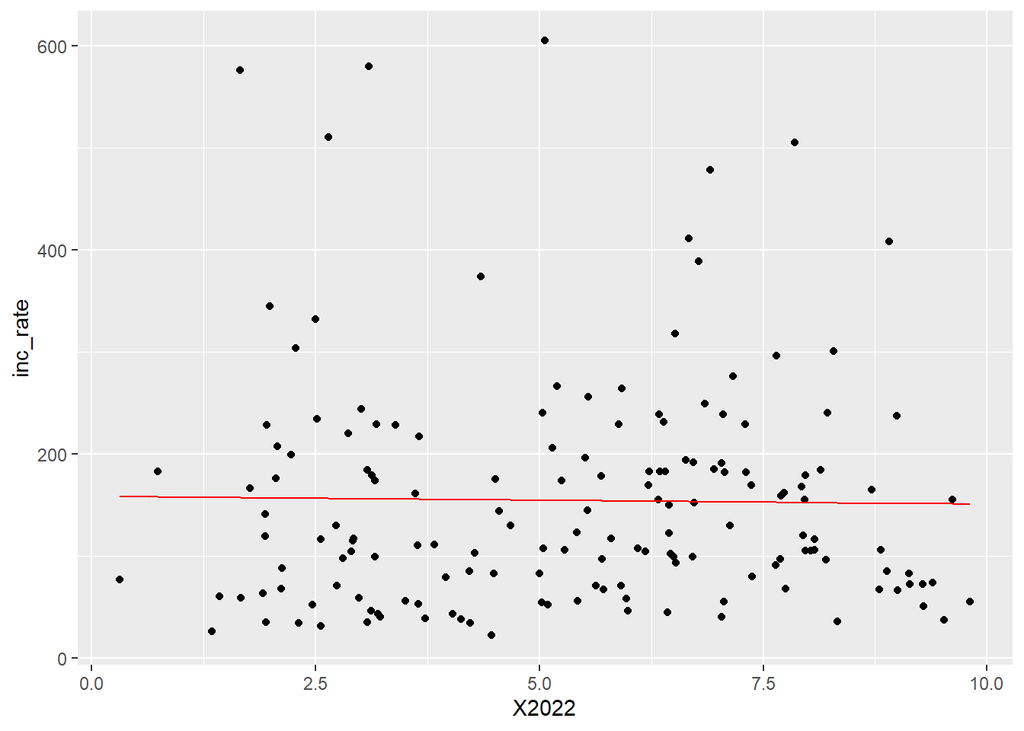

```r
ggplot(reg2_df) + geom_point(aes(X2022, inc_rate)) + geom_line(aes(X2022, reg2_lm$fitted.values), color="red")
```

Again, it fits the regression statistics. We see a lot of variance in the y-axis and no strong connection (positive or negative). The regression line is almost flat. Based on this data, it seems there is no connection between the two.

6.a. We will now calculate the empirical CDF function of X, where X is the random variable that represents the GDP of a random country:

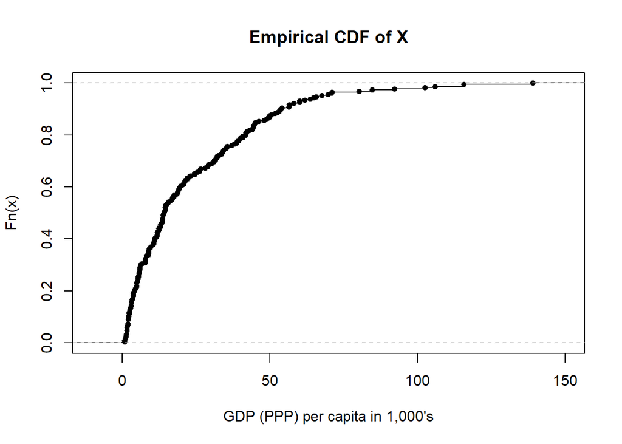

```r
numbers = as.numeric(gsub(",","",df_gdp$CIA.8..9..10.)[-1]) / 10^3
ecdf_1 <- ecdf(numbers)
plot(ecdf_1, xlab = "GDP (PPP) per capita in 1,000's", main = "Empirical CDF of X", cex = 0.75, col = "black")
```

We see that the probability of a X being a country with a GDP of below 25,000 is roughly 60%, and for a GDP below 50,000 is roughly 85%. We can also see in the plot that the countries with a GDP above 75,000 are a small minority of all countries in the world.

6.b. Next, We calculate the empirical CDF function of Y, where Y is the random variable that represents the GDP of a randomly selected person out of all people in the world.

We denote by $p_{j}$ the population size of country j, and $P=\sum_{i=1}^{n}p_{i}$ is the population of the world.

Then, the empirical CDF of Y is defined as:
$$\widehat{F}_{n}\left(y\right)=\frac{1}{n}\sum_{j=1}^{n}1_{\left\{
y_{j}\leq y\right\} }=\frac{1}{n}\sum_{j=1}^{n}1_{\left\{ x_{j}\leq
x\right\} }\cdot\frac{p_{j}}{\sum_{i=1}^{n}p_{i}}
=\frac{1}{n}\sum_{j=1}^{n}1_{\left\{ x_{j}\leq x\right\}
}\cdot\frac{p_{j}}{P}$$

We then plot $\widehat{F}_{n}\left(y\right) \sim GDP \ (PPP) \ per \ capita$.

The calculations are in the following code chunk:

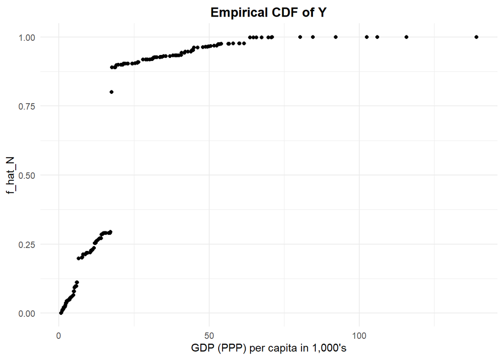

```r
#  Inner join to include all rows with data on both population size and GDP
df_gdp_pop_temp <- list(df_gdp, df_pop)
df_gdp_pop <- df_gdp_pop_temp %>% reduce(inner_join, by='Country')
names(df_gdp_pop)[7] <- "CIA.est"
df_gdp_pop = df_gdp_pop[,c("Population","CIA.est")]
df_gdp_pop$Population <- as.numeric(gsub(",","",df_gdp_pop$Population))
df_gdp_pop$CIA.est <- as.numeric(gsub(",","",df_gdp_pop$CIA.est)) / 10^3

# Manually calculating the ECDF values
N <- length(df_gdp_pop$Population)
f_hat_N <- rep(c(1), times = N)
for(i in 1:N){
  f_hat_N[i] = sum(df_gdp_pop$Population[which(df_gdp_pop$CIA.est <= df_gdp_pop$CIA.est[i])]) / sum(df_gdp_pop$Population)
}

# Combining the ECDF vector to the data frame
df_gdp_pop = cbind(df_gdp_pop, f_hat_N)

# Plotting the ECDF vs. the GDP in 1,000's
ggplot(data=df_gdp_pop, aes(x=CIA.est, y=f_hat_N)) +
  geom_point() +
  ggtitle("Empirical CDF of Y") +
  theme_minimal() +
  theme(plot.title=element_text(hjust=0.5, vjust=0.5, face='bold')) +
  labs(x = "GDP (PPP) per capita in 1,000's")
```

Alternatively, we can use the spatstat.geom package and with the help of ewcdf calculate the Empirical Weighted CDF as in the following chunk:

```r
# Using ewcdf from spatstat.geom package
install.packages("spatstat.geom")
```

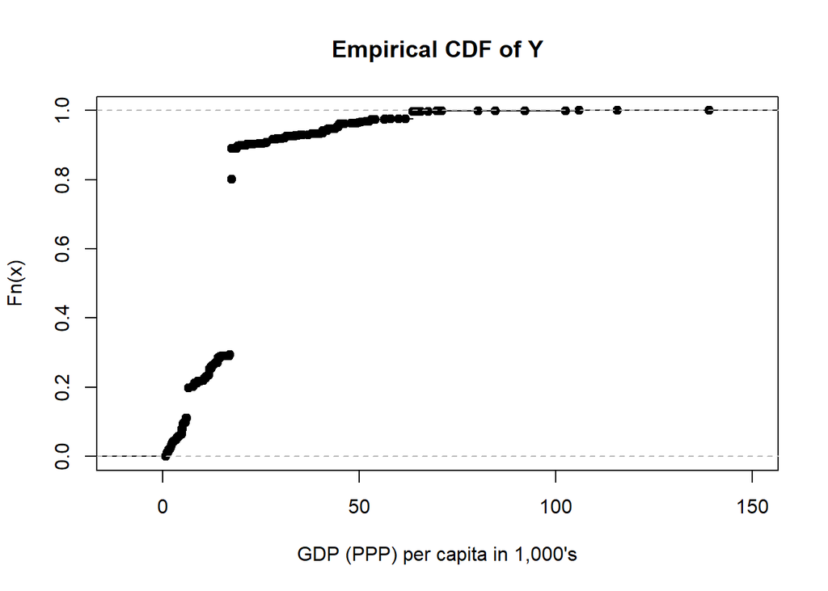

```r
ecdf_2 <- ewcdf(df_gdp_pop$CIA.est, weights = df_gdp_pop$Population / sum(df_gdp_pop$Population))

# Plotting the ecdf
plot(ecdf_2, xlab = "GDP (PPP) per capita in 1,000's", main = "Empirical CDF of Y", cex = 1, col = "black")
```

We note that both plots and calculations are identical. We can also observe that there is a large jump from the 30% to the 80% in $\hat{F}_N$, which we presume represents the fact that most of the people in the world live in countries with a low GDP, such as: China, India, Indonesia, Pakistan and more. So we end up with the majority of the world (80%) below a GDP of 20,000.

6.c. As we did in the previous section, we calculate the empirical CDF function of Z, where Z is the random variable that represents the GDP of a randomly selected person, where the person’s location is selected randomly from all places locations in the world.

We denote by $a_{j}$ the population area (in $km^2$) of country j, and $A=\sum_{i=1}^{n}a_{i}$ is the total area of the world.

Then, the empirical CDF of Y is defined as:
$$\widehat{F}_{n}\left(z\right)=\frac{1}{n}\sum_{j=1}^{n}1_{\left\{
z_{j}\leq z\right\} }=\frac{1}{n}\sum_{j=1}^{n}1_{\left\{ x_{j}\leq
x\right\} }\cdot\frac{a_{j}}{\sum_{i=1}^{n}a_{i}}
=\frac{1}{n}\sum_{j=1}^{n}1_{\left\{ x_{j}\leq x\right\}
}\cdot\frac{a_{j}}{A}$$

We then plot $\widehat{F}_{n}\left(z\right) \sim GDP \ (PPP) \ per \ capita$.

We will use the spatstat.geom package here as well:

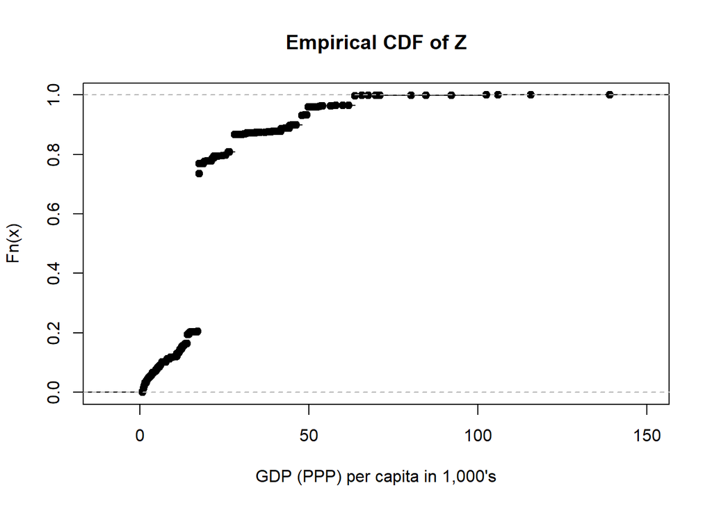

```r
#  Inner join to include all rows with data on both population size and GDP
df_gdp_area_temp <- list(df_gdp, df_area)
df_gdp_area <- df_gdp_area_temp %>% reduce(inner_join, by='Country')
names(df_gdp_area)[7] <- "CIA.est"
names(df_gdp_area)[11] <- "Land (km)"
df_gdp_area = df_gdp_area[,c("Land (km)","CIA.est")]

# removing the squared miles data from the Land (km) column
df_gdp_area$`Land (km)` <- df_gdp_area$`Land (km)` %>% str_replace_all("\\(.+\\)", "") %>% str_trim()
df_gdp_area$`Land (km)` <- as.numeric(gsub(",","",df_gdp_area$`Land (km)`))
df_gdp_area$CIA.est <- as.numeric(gsub(",","",df_gdp_area$CIA.est)) / 10^3
df_gdp_area = na.omit(df_gdp_area)

# Using ewcdf from spatstat.geom package
ecdf_3 <- ewcdf(df_gdp_area$CIA.est, weights = df_gdp_area$`Land (km)` / sum(df_gdp_area$`Land (km)`))

# Plotting the ecdf
plot(ecdf_3, xlab = "GDP (PPP) per capita in 1,000's", main = "Empirical CDF of Z", cex = 1, col = "black")
```

If we look at the top 10 countries in terms of area, we have Russia, Canada, China, USA, Brazil, Australia, India, Argentina, Kazakhstan and Algeria.

Among those 10 countries, only Canada, USA and Australia have a high GDP.

So we end up with the majority of the world’s area (80%) belonging to countries with a low GDP (below 20,000).

We now compare the percentiles (25%, 50%, 75%) of X, Y and Z:

```r
quantile(ecdf_1, c(0.25, 0.5, 0.75))
```

```
##    25%    50%    75%
##  5.425 14.150 35.200
```

```r
quantile(ecdf_2, c(0.25, 0.5, 0.75))
```

```
##  25%  50%  75%
## 11.9 17.5 17.5
```

```r
quantile(ecdf_3, c(0.25, 0.5, 0.75))
```

```
##  25%  50%  75%
## 17.5 17.5 17.6
```

As we can see both on the graph and in the r calculations, Y and Z are almost identical in the 50% and 75% percentiles, and similar in the 25% percentile. This is due to the explanations we provided above, being that the majority of the world’s population is situated in low-GDP countries, and the majority of large-area countries tend to be low-GDP countries as well.

7

```r
install.packages("rworldmap")
# organize data frame
to_map <- df_country[,c(3,5:(length(df_country)-1))]

# add the mean and difference columns to data frame
to_map = cbind(to_map, rowMeans(to_map[,2:length(to_map)]), (to_map$X2022 - to_map$X2006))

# view the names of the data frame
names(to_map)
```

```
##  [1] "Country"
##  [2] "X2022"
##  [3] "X2021"
##  [4] "X2020"
##  [5] "X2019"
##  [6] "X2018"
##  [7] "X2017"
##  [8] "X2016"
##  [9] "X2015"
## [10] "X2014"
## [11] "X2013"
## [12] "X2012"
## [13] "X2011"
## [14] "X2010"
## [15] "X2008"
## [16] "X2006"
## [17] "rowMeans(to_map[, 2:length(to_map)])"
## [18] "(to_map$X2022 - to_map$X2006)"
```

```r
# updates the names of the 2 added columns
names(to_map)[17] = "Average-06-22"
names(to_map)[18] = "Difference-06-22"

# create world map
sPDF <- joinCountryData2Map(to_map
              , joinCode = "NAME"
             , nameJoinColumn = "Country"
              )
```

```
## 165 codes from your data successfully matched countries in the map
## 2 codes from your data failed to match with a country code in the map
## 78 codes from the map weren't represented in your data
```

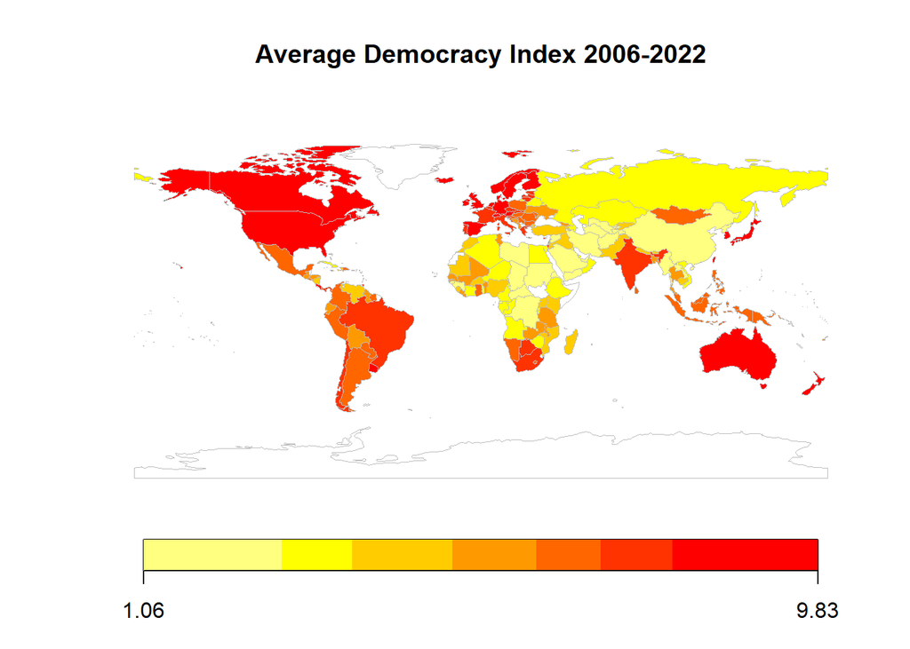

```r
mapCountryData( sPDF
              , nameColumnToPlot="Average-06-22"
              , mapTitle="Average Democracy Index 2006-2022"
              )
```

In the map of the average DI, we see the countries in the western world tend to have a higher DI, whereas former USSR and African countries tend to have a lower DI.

We now look at the map of the difference in DI:

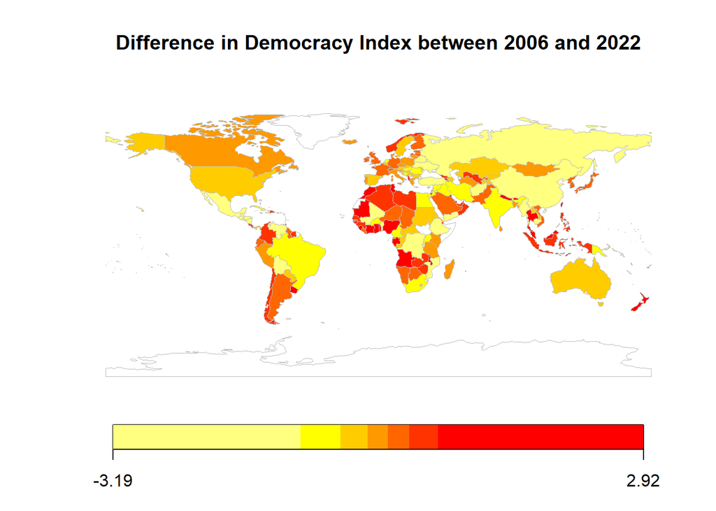

```r
mapCountryData( sPDF
              , nameColumnToPlot="Difference-06-22"
              , mapTitle="Difference in Democracy Index between 2006 and 2022"
              )
```

Here, we see that most countries in the western world tend to have very little change, whereas many underdeveloped countries in Africa, South America and Southeast Asia have an increase in DI. We note the decline in DI in various countries as well, including: Russia, Mexico, China, Turkey and some more.

8.a.

```r
# Cleaning irrelevant rows and joining
df_comp_tojoin <- df_comp[-c(1,2,27,76,113),]
full_df_comp <- full_join(full_df_country, df_comp_tojoin, "Country")
head(full_df_comp, 5)
```

```
##         Region.x X2022.rank       Country    Regime.type.x X2022 X2021 X2020
## 1  North America         12        Canada   Full democracy  8.88  8.87  9.24
## 2  North America         30 United States Flawed democracy  7.85  7.85  7.92
## 3 Western Europe         20       Austria   Full democracy  8.20  8.07  8.16
## 4 Western Europe         36       Belgium Flawed democracy  7.64  7.51  7.51
## 5 Western Europe         37        Cyprus Flawed democracy  7.38  7.43  7.56
##   X2019 X2018 X2017 X2016 X2015 X2014 X2013 X2012 X2011 X2010 X2008 X2006
## 1  9.22  9.15  9.15  9.15  9.08  9.08  9.08  9.08  9.08  9.08  9.07  9.07
## 2  7.96  7.96  7.98  7.98  8.05  8.11  8.11  8.11  8.11  8.18  8.22  8.22
## 3  8.29  8.29  8.42  8.41  8.54  8.54  8.48  8.62  8.49  8.49  8.49  8.69
## 4  7.64  7.78  7.78  7.77  7.93  7.93  8.05  8.05  8.05  8.05  8.16  8.15
## 5  7.59  7.59  7.59  7.65  7.53  7.40  7.29  7.29  7.29  7.29  7.70  7.60
##   X2006.Regime.type UN.Region IMF.5..6. IMF.5..6..1 World.Bank.7.
## 1    Full democracy  Americas    60,177        2023        52,085
## 2    Full democracy  Americas    80,035        2023        69,288
```

[output cut: 51 more lines]

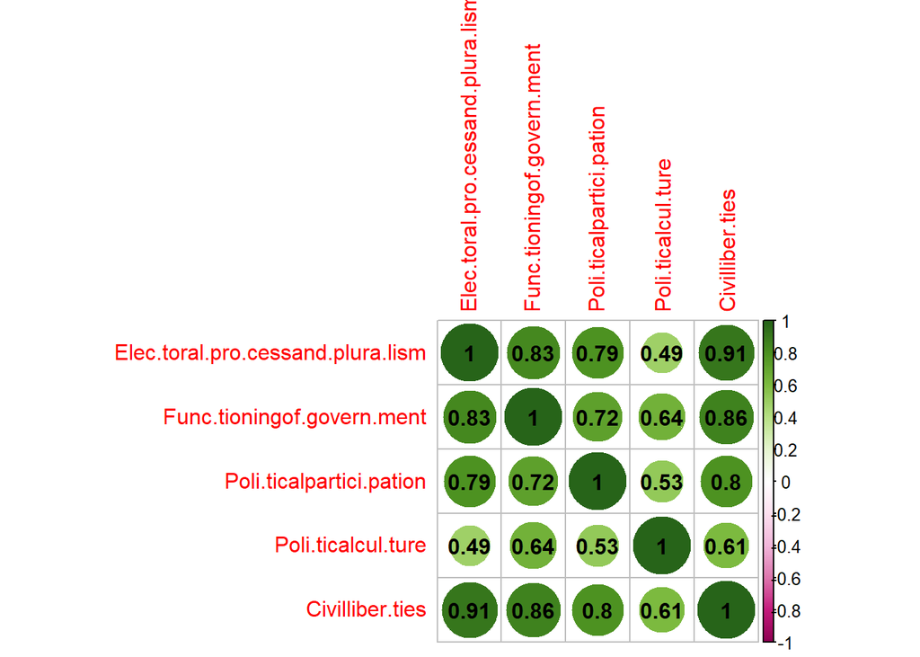

```r
# Subsetting dataframe and Clearing NAs
reg_comp_df  <- full_df_comp %>% drop_na(Civilliber.ties) %>% drop_na(CIA.est)

#Converting to numeric
n <- ncol(reg_comp_df)
reg_comp_df$CIA.est %<>% str_replace_all(fixed(","), "") %>% as.numeric()
reg_comp_df[,c(26,(n-4):n)] <- lapply(reg_comp_df[,c(26,(n-4):n)], as.numeric)

# Creating corr matrix
corr_mat <- cor(reg_comp_df[,(n-4):n])
corrplot(corr_mat, addCoef.col = "black", col = COL2("PiYG"))
```

We can see there are some strongly correlated components such as “Electoral process and pluralism” with “Civil liberties” or “Functioning of government” with “Civil liberties” (Correlation over 0.85). Overall, the darker colors dominates the heatmap, meaning there is some correlation between the components. Also, we can see that all the pairs with relatively low correlation include “Political culture”. It means that this component probably has weaker linear connection to the others. It is also noticeable that all colors are green, meaning all correlations are positive.

Next, we will run a multiple linear regression trying to predict the GDP of each country based on the 5 components:

8.b.

```r
reg_comp <- lm(CIA.est ~ Elec.toral.pro.cessand.plura.lism + Func.tioningof.govern.ment + Poli.ticalpartici.pation + Poli.ticalcul.ture + Civilliber.ties, reg_comp_df)

summary(reg_comp)
```

```
##
## Call:
## lm(formula = CIA.est ~ Elec.toral.pro.cessand.plura.lism + Func.tioningof.govern.ment +
##     Poli.ticalpartici.pation + Poli.ticalcul.ture + Civilliber.ties,
##     data = reg_comp_df)
##
## Residuals:
##    Min     1Q Median     3Q    Max
## -33232  -9248  -2115   7528  66780
##
## Coefficients:
##                                   Estimate Std. Error t value Pr(>|t|)
## (Intercept)                       -16119.7     4524.9  -3.562 0.000484 ***
## Elec.toral.pro.cessand.plura.lism  -2990.1      888.6  -3.365 0.000957 ***
## Func.tioningof.govern.ment          4905.0     1033.2   4.747 4.52e-06 ***
## Poli.ticalpartici.pation             719.7     1078.9   0.667 0.505687
## Poli.ticalcul.ture                  2722.1      919.9   2.959 0.003552 **
## Civilliber.ties                     2319.3     1319.1   1.758 0.080608 .
## ---
## Signif. codes:  0 '***' 0.001 '**' 0.01 '*' 0.05 '.' 0.1 ' ' 1
##
## Residual standard error: 16390 on 161 degrees of freedom
## Multiple R-squared:  0.4739, Adjusted R-squared:  0.4575
## F-statistic:    29 on 5 and 161 DF,  p-value: < 2.2e-16
```

Now, we’ll find outliers:

```r
# Bind the residual vector to the dataframe
e <- resid(reg_comp)
reg_comp_df <- cbind(reg_comp_df, e)
```

```r
# Display outliers (high/low residuals)
reg_comp_df %>% arrange(e) %>% select(Country, e) %>% top_n(-5)
```

```
##              Country         e
## 127            Benin -33232.25
## 131       Cape Verde -28007.89
## 76           Uruguay -25231.03
## 147            Kenya -24687.07
## 97  Papua New Guinea -24433.86
```

```r
reg_comp_df %>% arrange(desc(e)) %>% select(Country, e) %>% top_n(5)
```

```
##                  Country        e
## 15            Luxembourg 66780.14
## 119                Qatar 65853.23
## 99             Singapore 59391.55
## 13               Ireland 53882.79
## 124 United Arab Emirates 42403.64
```

```r
reg_comp_df %>% arrange(desc(X2022)) %>% filter(Region.x == "Sub-Saharan Africa") %>% select(Country, X2022)
```

```
##                      Country X2022
## 154                Mauritius  8.14
## 128                 Botswana  7.73
## 131               Cape Verde  7.65
## 162             South Africa  7.05
## 156                  Namibia  6.52
## 144                    Ghana  6.43
## 148                  Lesotho  6.19
## 151                   Malawi  5.91
## 166                   Zambia  5.80
## 160                  Senegal  5.72
## 150               Madagascar  5.70
## 149                  Liberia  5.43
## 163                 Tanzania  5.10
## 147                    Kenya  5.05
```

[output cut: 28 more lines]

but much lower GDP than the model predicts.

- Economy (liberal/socialist) - The economic approach of a country obviously influences the GDP, but not necessarily in the same way as it influences the DI. For example, Qatar and UAE are rich countries (because of oil) therefore they have relatively good economy, yet very low DI.